# Plotting xgboost Performance Trajectories

John Mount

2018-01-01

Below is the standard performance trajectory history from `xgboost`.

```r
library("xgboost")
library("WVPlots")
library("seplyr")
library("sigr")
library("kableExtra")
options(knitr.table.format = "html")

# From:
# http://xgboost.readthedocs.io/en/latest/R-package/xgboostPresentation.html
data(agaricus.train,
     package='xgboost')
data(agaricus.test,
     package='xgboost')
train <- agaricus.train
test <- agaricus.test
epochs <- 20

bstSparse <-
  xgboost(data = train$data,
          label = train$label,
          max.depth = 2,
          eta = 1,
          nthread = 2,
          nround = epochs,
          objective = "binary:logistic")
head(bstSparse$evaluation_log)
```

```
##    iter train_error
## 1:    1    0.046522
## 2:    2    0.022263
## 3:    3    0.007063
## 4:    4    0.015200
## 5:    5    0.007063
## 6:    6    0.001228
```

Next we re-evaluate the model performance trajectory both on training and test data using metrics of our own choosing.

```r
score_model <- function(model,
                        epoch,
                        data,
                        datasetname) {
  pred <- predict(model,
                  newdata = data$data,
                  ntreelimit = epoch)
  acc <- mean(data$label ==
                ifelse(pred>=0.5,
                       1.0,
                       0.0))
  dev <- sigr::calcDeviance(pred,
                            ifelse(data$label>=0.5,
                                   TRUE,
                                   FALSE))
  auc <- sigr::calcAUC(pred,
                       ifelse(data$label>=0.5,
                              TRUE,
                              FALSE))
  data.frame(dataset = datasetname,
             epoch = epoch,
             accuracy = acc,
             mean_deviance = dev/nrow(data$data),
             AUC = auc,
             stringsAsFactors = FALSE)
}

score_model_trajectory <- function(model,
                                   epochs,
                                   data,
                                   datasetname) {
  evals <- lapply(epochs,
                  function(epoch) {
                    score_model(model,
                                epoch,
                                data,
                                datasetname)
                  })
  r <- dplyr::bind_rows(evals)
  colnames(r) <- paste(datasetname,
                       colnames(r),
                       sep = "_")
  r
}

eval <-
  cbind(
    score_model_trajectory(bstSparse,
                           seq_len(epochs),
                           train,
                           "train"),
    score_model_trajectory(bstSparse,
                           seq_len(epochs),
                           test,
                           "test"))
cols <- c("train_epoch", "train_accuracy",
          "train_mean_deviance", "train_AUC",
          "test_accuracy", "test_mean_deviance",
          "test_AUC")
eval <- eval[, cols, drop = FALSE]
knitr::kable(head(eval))
```

| train_epoch | train_accuracy | train_mean_deviance | train_AUC | test_accuracy | test_mean_deviance | test_AUC |
| --- | --- | --- | --- | --- | --- | --- |
| 1 | 0.9534777 | 0.4667512 | 0.9582280 | 0.9571695 | 0.4533720 | 0.9603733 |
| 2 | 0.9777368 | 0.2733163 | 0.9814132 | 0.9782744 | 0.2757484 | 0.9799301 |
| 3 | 0.9929372 | 0.1650616 | 0.9970700 | 0.9937927 | 0.1609212 | 0.9985184 |
| 4 | 0.9847996 | 0.1129484 | 0.9987570 | 0.9819988 | 0.1166577 | 0.9989428 |
| 5 | 0.9929372 | 0.0830270 | 0.9992985 | 0.9937927 | 0.0765738 | 0.9998302 |
| 6 | 0.9987717 | 0.0592123 | 0.9995853 | 1.0000000 | 0.0532618 | 1.0000000 |

At this point we have gotten to the very wide table one might expect to have on hand from a training procedure. So only the code this point and below is actually the plotting procedure.

We can then plot the performance trajectory using [`WVPlots::plot_fit_trajectory()`](https://winvector.github.io/WVPlots/reference/plot_fit_trajectory.html) plot.

```r
cT <- dplyr::tribble(
  ~measure,                 ~training,             ~validation,
  "minus mean deviance",    "train_mean_deviance", "train_mean_deviance",
  "accuracy",               "train_accuracy",      "test_accuracy",
  "AUC",                    "train_AUC",           "test_AUC"
)
cT %.>%
  knitr::kable(.) %.>%
  kable_styling(., full_width = F) %.>%
  column_spec(., 2:3, background = "yellow")
```

| measure | training | validation |
| --- | --- | --- |
| minus mean deviance | train_mean_deviance | train_mean_deviance |
| accuracy | train_accuracy | test_accuracy |
| AUC | train_AUC | test_AUC |

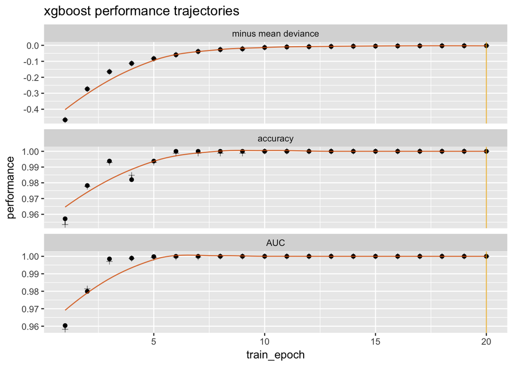

```r
plot_fit_trajectory(eval,
                    column_description = cT,
                    epoch_name = "train_epoch",
                    needs_flip = "minus mean deviance",
                    pick_metric = "minus mean deviance",
                    title = "xgboost performance trajectories")
```

Obviously this plot needs some training to interpret, but that is pretty much the case for all visualizations.

The ideas of this plot include:

- All facets have the same interpretation: “up is better.” This makes it easier to relate the shapes in one pane to the other.
- The only horizontal solid curve rendered is the validation (or hold-out) performance. The validation performance is the primary item of interest, so it gets a unique presentation.
- The training performance is represented as the upper boundary of the shaded region and with the pluses and vertical strokes (not visible in this example, as the two are close or reversed here).
- A vertical line is added at the best epoch picked by the “minus mean deviance” metric (this can be turned off or changed).
- An optional additional training over-fit penalized dashed curve is added. The default is: this is the validation score minus `10%` of the excess generalization error (the difference in training and validation performance).